# Employee Attrition Analysis

## Introduction

**Employee** is an individual hired as a part-timer of full-timer to complete a specific task, in exchange of wages or salary.

**Employee resignation** normally happened due to attrition, push factors or pull factors. This is indeed a normal phenomenon but abnormal if resignation happens frequently.

**Impact:**

- Loss of talents which indirectly affecting the business performance and productivity.
- Negative impacts towards organizations in terms of hiring cost, training effort and time invested in long run.

**Motivation:**

- Frequent resignations happened among our working companies.
- The Great Resignation (2021).
- To have a better understanding of the factors that cause employee attrition.

## Project Information

**Data Source:**

- Kaggle - [IBM Human Resource Data](https://www.kaggle.com/datasets/pavansubhasht/ibm-hr-analytics-attrition-dataset)

**Questions:**

1. What is the relationship between the factors that cause employee attrition?
2. Which are the significant factors that influence the employee turnover?

**Target Audience:**

1. Company or Organization Human Resource Department
2. Ministry of Human Resource (MOHR) / Policymakers

**Significance:**

1. Insightful information on the root causes of employee churn.
2. Important guideline for employee retention strategies and enhancement of employee benefits.
3. Act as a tool to alter employee benefits when recruiting potential talents.

## [ShinyApp](https://mandygui.shinyapps.io/EmployeeAttritionAnalysis/)

- **Descriptive Analysis**
- **Exploratory Data Analysis**

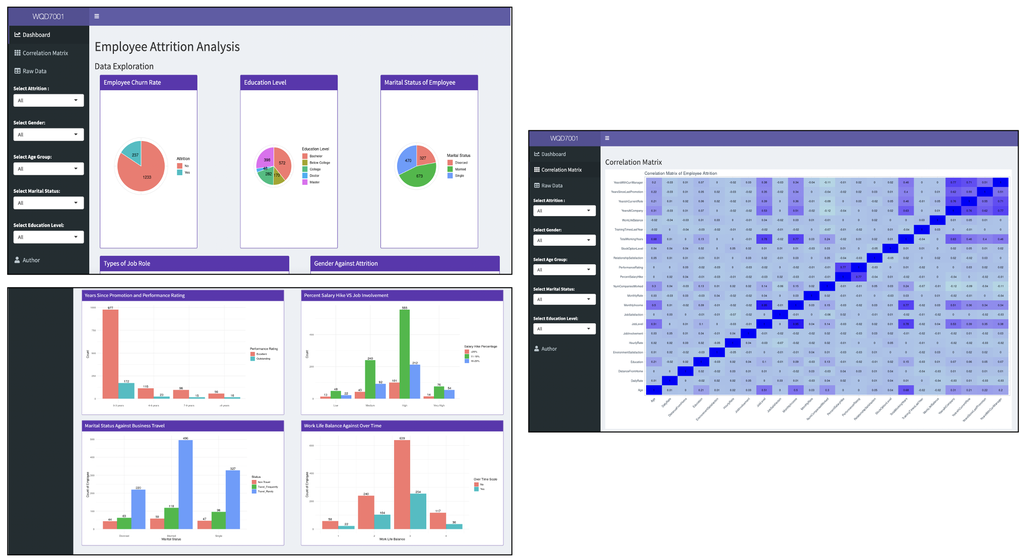

## Summary

**Churning factors:**

- Work over time -> no work life balance.
- Job satisfaction & working environment.

**Factors of not churning**:

- Working Experience (Age, Income, Job Level)
- Company / Organisation (Boss, Role, Promotion).

**Challenges:**

1. Unbalanced data as the count of employee churner is much lesser in the dataset.
2. Difficult to get real employee information from companies.

**Future Work:**

1. Build prediction model to predict potential employee churner
2. Include working mode (hybrid or remote) as factor in analysis

**Link:**

[ShinyApp](https://mandygui.shinyapps.io/EmployeeAttritionAnalysis/) | [Codes](https://github.com/MandyMiowWan/Employee-Attrition)